# Introducción al Diseño Estadístico de Experimentos

Estudio R

Marzo de 2018

# Conceptos básicos

- **Experimento:** procedimiento mediante el cual se controlan determinadas condiciones y es posible verificar (apoyar, rechazar o modificar) ciertas conjeturas, que se denominan **hipótesis**).
  - **Experimento determinístico**: aquél que bajo las mismas condiciones, arroja los mismos resultados.
  - **Experimento aleatorio:** aquél que bajo las mismas condiciones, arroja resultados diferentes.
- **Unidad experimental:** muestra utilizada para generar valores representativos del resultado del experimento.

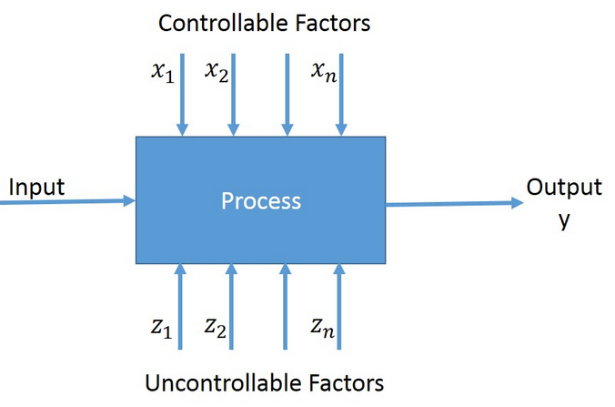

- **Variable respuesta:** variable objetivo, a través de la misma, es posible conocer el efecto o el resultado de determinado experimento.
- **Factores controlables:** son variables que se pueden fijar en determinados niveles. Usualmente controlados bajo experimentación u operación normal del proceso de interés; se caracterizan por posibilitar el cambio o la manipulación de su nivel de operación.
- **Factores no controlables (ruido):** variables o características del fenómenos bajo experimentación, que no se pueden controlar.
- **Tratamiento:** los diferentes valores que se asignan a cada factor bajo estudio, se denominan *niveles*. La combinación de los niveles de los factores de interés, se conoce como *tratamiento*. El tratamiento, es una de las formas que durante el experimento toma el factor.
  - **Tratamiento control:** tratamiento de útilidad para comparar.
- **Error experimental:** parte de la variabilidad observada que no es posible explicar a través de los factores estudiados. En ese orden de ideas, **siempre** existirán casusas comunes o aleaotorias, que determinan la **variabilidad natural del fenómeno**.
- **Repetición:** una repetición, es el número de veces que aparece el tratamiento en el experimento. Importante para **aumentar** la precisión del experimento, controlar el error experimental y disminuir la desviación estándar de la media.
- **Diseños:** de acuerdo con la asignación de tratamientos a las unidades experimentales y, basados en el número de datos para los factores de interés (en sus niveles), podremós hablar de dos tipos de diseños:
  - **Diseño balanceado:** todos los niveles poseen la misma cantidad de datos.
  - **Diseño desbalanceado:** todos los niveles no poseen la misma cantidad de datos.
- **Etapas de un experimento:**
  - **1. Objetivo:** definir el objetivo de estudio; entender y acotar el problema de interés.
  - **2. Variables respuesta:** elección de variables respuesta que contribuyan a la caracterización del fenómeno.
  - **3. Factores:** utilizar toda la información disponible para determinar los factores del experimento.
  - **4. Niveles:** seleccionar los niveles de cada factor. Determinar el número de repeticiones por tratamiento.
  - **5. Planificación del trabajo experimental:** forma operativa de desarrollar el experimento.
  - **6. Realizar el experimento.**

| Item | Descripción |
| --- | --- |
| **Integrantes** | Desarroladores del experimento |
| **Título del experimento** | Conciso, diciente y específico |
| **Objetivos del experimento** | Insesgados, específicos, cuantificables y de uso práctico |
| **Variables respuesta** | Valores usuales de operación, distribución o rango usual, precisión o rango de medición, instrumento de medida y cómo será tomada |
| **Factores** | Factores con cada uno de los niveles, distribución y rango de operación común, precisión o rango en la cual serán medidos. |
| **Diseño** | Un factor, factorial, bloques, parcelas divididas, cuadro latino, entre otros |

- **Planeación de un experimento:**
  - **¿Cuál es mi objetivo?**
  - **¿Qué quiero saber?**
  - **¿Por qué quiero saberlo?**
  - **¿Cómo lo voy a realizar?**

# Métodos Estadísticos

- **Historia:**
  - Método científico
    - Observación
    - Inducción
    - Hipótesis
    - Experimentación
    - Antítesis
    - Teoría científica
  - **Ronald A. Fisher**
  - **George Box** aportes importantes en inferencia bayesiana
  - **Genichi Taguchi** con el diseño robusto
- **Consideraciones prácticas:**
  - El conocimiento específico es vital
  - Significancia estadística y significancia práctica
  - Experimentación secuencial
- **Principios fundamentales:**
  - **Control local:** reducir el error experimental.
  - **Replicación:** medio para estimar la varianza del error experimental.
  - **Aleatorización:** estimación válida de la varianza del error experimental.

**Clasificiación de diseños experimentales:**

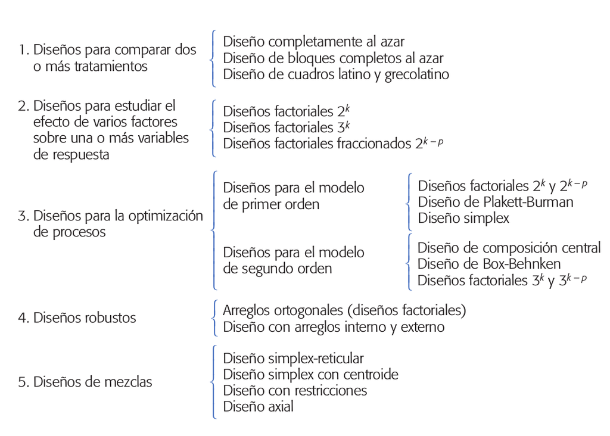

**Nota:** tomado del libro *Análisis y diseño de experimentos* de Humberto Pulido y Román de la Vara.

- **Consideraciones matemáticas:**
  - Variabilidad observada $\sigma^2$
  - Descomposición de la variabilidad $\sigma^2$
    - Suma de cuadrados total
    - Suma de cuadrados entre grupos
    - Suma de cuadrados residual (dentro de grupos)
  - **Efectos fijos**
  - **Efectos aleatorios**
  - **Modelos lineales** $y=mx+b$
    - Supuesto de normalidad
    - Supuesto de homocedasticidad
    - Supuesto de independencia
  - **Modelos de efectos fijos**
  - **Modelo de efectos aleatorios**
  - **Modelos mixtos**
  - **Comparaciones múltiples**
    - Tukey
    - Dunnet
    - LSD (distancia mínima significativa de Fisher)
    - Duncan
    - Bonferroni

# Elementos de Inferencia Estadística

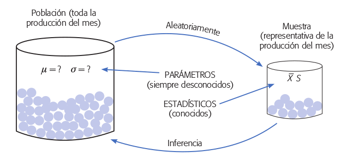

- **Distribuciones de probabilidad:** las distribuciones de probabilidad o distribución de una variable aleatoria $X$, asocia el conjunto de valores posibles de $X$ (rango de $X$), con la probabilidad relacionada a cada uno de estos valores y son representados a través de una función (fómula matemática)
- **Ejemplo:** si la variable aleatoria está dada por el estadístico $\bar{X}$, conocer su distribución de probabilidad posibilita saber cuáles son los valores que puede tomar $\bar{X}$ y cuáles son más probables. A través de la distribución de probabilidad, es posible describir o acotar los posibles valores de un estadístico muestral, con la finalidad de rechazar o apoyar determinadas hipótesis, o bien, hacer estimaciones poblacionales.
  - **Distribución normal:**
    - Parámetro $\mu$
    - Parámetro $\sigma$
    - Normal estándar $\mu=0\ y\ \sigma=1$ –> $N(0,1)$
    - Simétrica

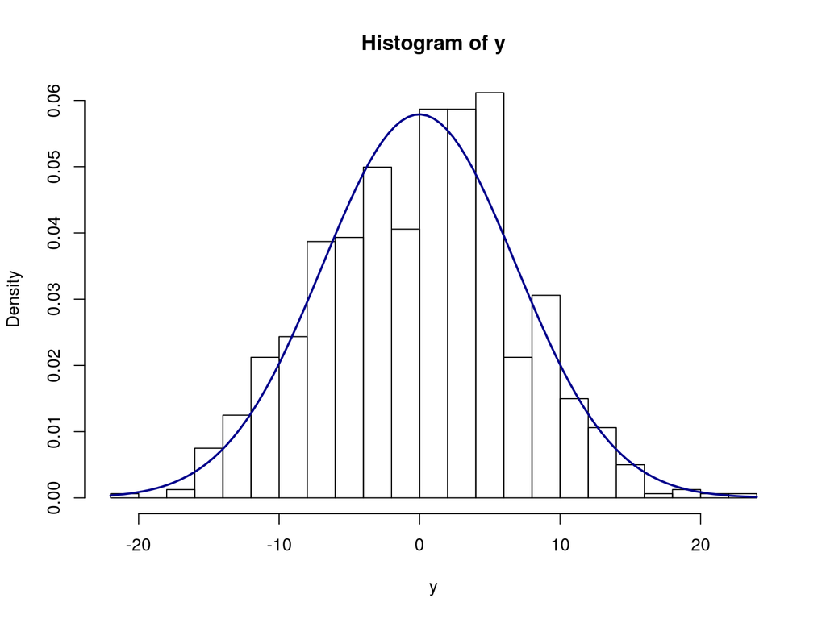

- **Distribución $t-Student$:**
  - Se define en términos de la distribución normal
  - Los parámetros que la definen son los grados de libertad
  - Inferencia sobre $\mu$ y $P$

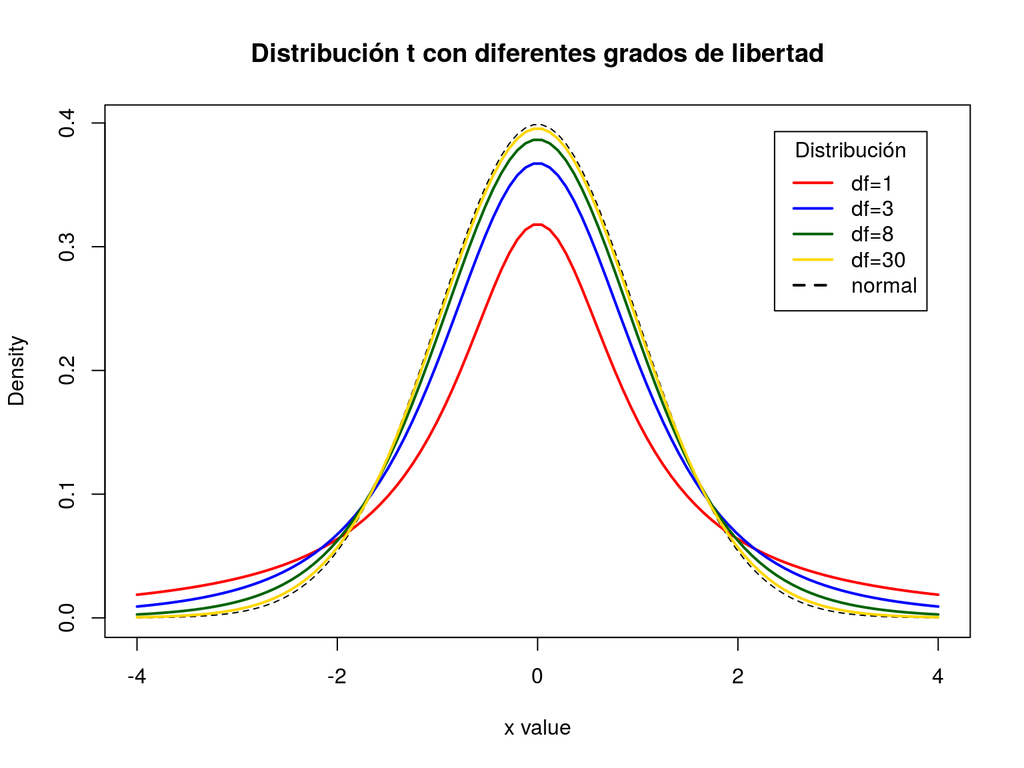

- **Distribución $\chi^2$:**
  - Se define en términos de la distribución normal
  - Los parámetros que la definen son los grados de libertad
  - Inferencia sobre $\sigma^2$

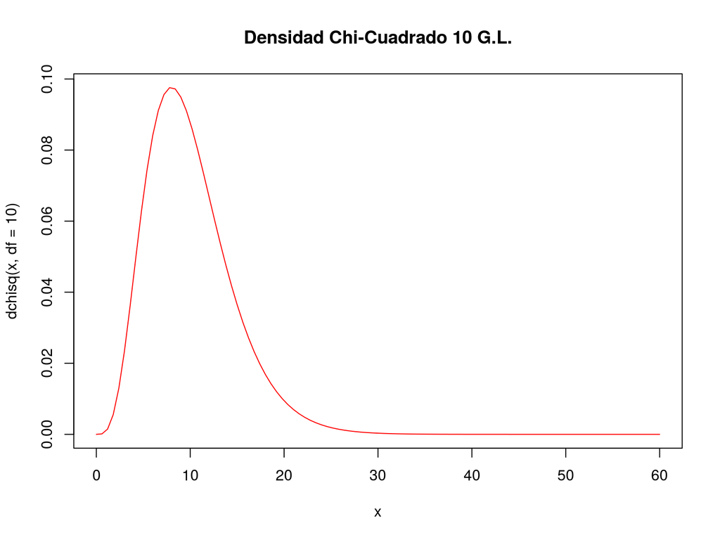

- **Distribución $F$**
  - Se define en términos de la distribución normal
  - Los parámetros que la definen son los grados de libertad
  - Comparar varianzas
  - Importante en diseño de experimentos (análisis de variabilidad)

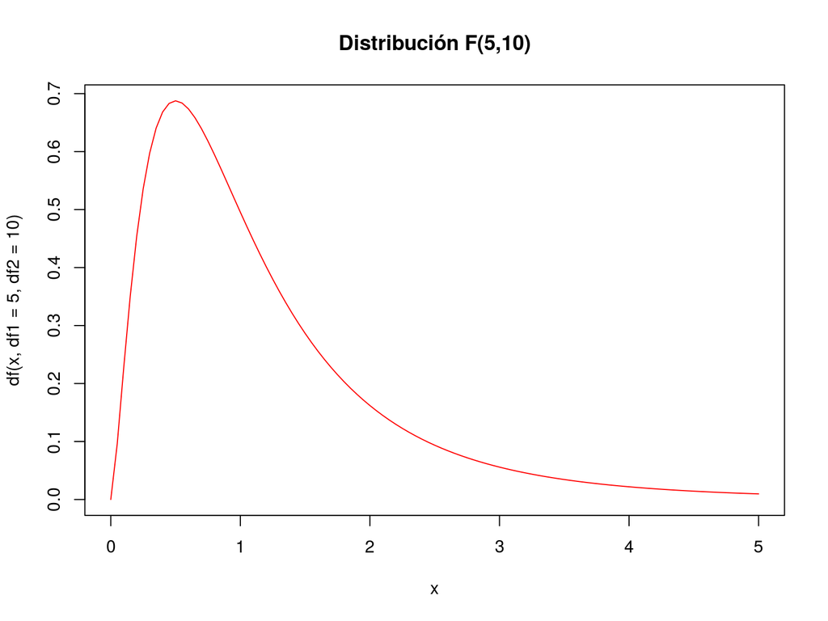

- **Tipos de muestras:**
  - Independientes
  - Pareadas
- **Esimación:**
  - **Estimación puntual:**
    - Parámetros $\mu,\ \sigma\ y\ P$
    - Estimadores puntuales $\mu=\bar{X}$, $\sigma^2=S^2$ y $P=x/n$
    - Alta exactitud
    - Baja precisión
  - **Estimación por intervalo:**
    - Intervalos $100(1-\alpha)$
    - Límite inferior
    - Límite superior
    - Baja exactitud
    - Alta precisión

Fórmulas para intervalos de confianza:

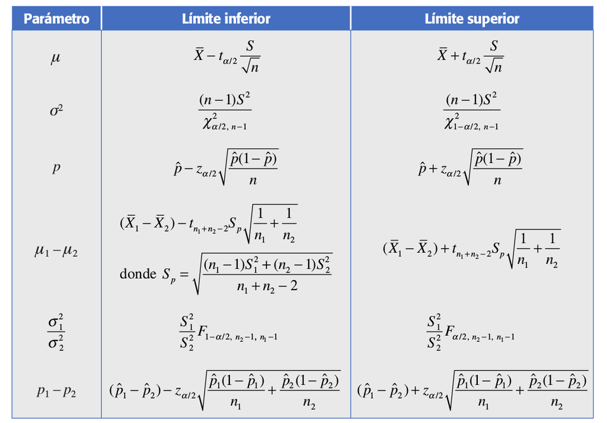

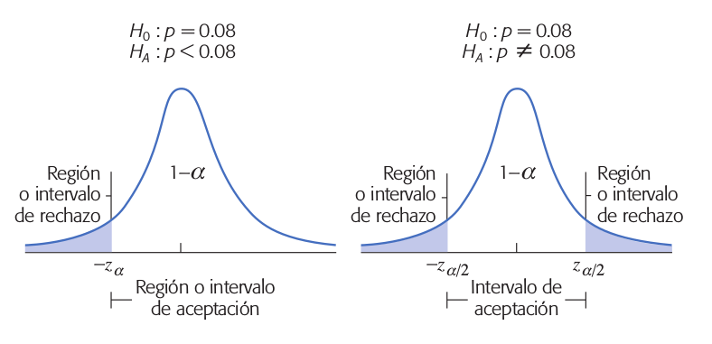

- Valor P.
  - $Si\ valor\ P\ <\ \alpha,\ entonces,\ existe\ evidencia\ para\ rechazar\ H_0$
  - $Si\ valor\ P\ >\ \alpha,\ entonces,\ NO\ existe\ evidencia\ para\ rechazar\ H_0$
  - $Si\ valor\ P\ =\ \alpha,\ entonces,\ posiblemente\ surge\ la\ necesidad\ de\ aumentar\ el\ tamaño\ de\ muestra$
- Intervalos de confianza
  - Contiene al cero
  - A la derecha del cero
  - A la izquierda del cero
- **Tipos de errores:**

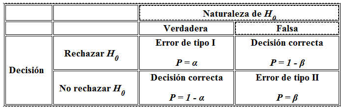

# Ejemplos con R

- **Ejemplo 1.1** el conjunto de datos `births` del paquete `openintro` contiene información sobre 150 nacimientos junto con información de las madres. Se pretende saber si existen diferencias estadísticamente signifcativas para el peso de los recien nacidos, entre madres fumadoras y no fumadoras.

| fAge | mAge | weeks | premature | visits | gained | weight | sexBaby | smoke |
| --- | --- | --- | --- | --- | --- | --- | --- | --- |
| 31 | 30 | 39 | full term | 13 | 1 | 6.88 | male | smoker |
| 34 | 36 | 39 | full term | 5 | 35 | 7.69 | male | nonsmoker |
| 36 | 35 | 40 | full term | 12 | 29 | 8.88 | male | nonsmoker |
| 41 | 40 | 40 | full term | 13 | 30 | 9 | female | nonsmoker |
| 42 | 37 | 40 | full term | NA | 10 | 7.94 | male | nonsmoker |
| 37 | 28 | 40 | full term | 12 | 35 | 8.25 | male | smoker |

**Solución:**

1. Planteamiento de hipótesis

$$H_0: \mu_f=\mu_nf$$
$$H_0: \mu_f\neq\mu_nf$$

2. Parámetro estimado

```r
tapply(births$weight, births$smoke, mean)
```

```
## nonsmoker    smoker
##    7.1795    6.7790
```

```r
fuma <- 6.7790
nofuma <- 7.1795
(diferencia <- fuma - nofuma)
```

```
## [1] -0.4005
```

3. Validar supuestos
   - Normalidad

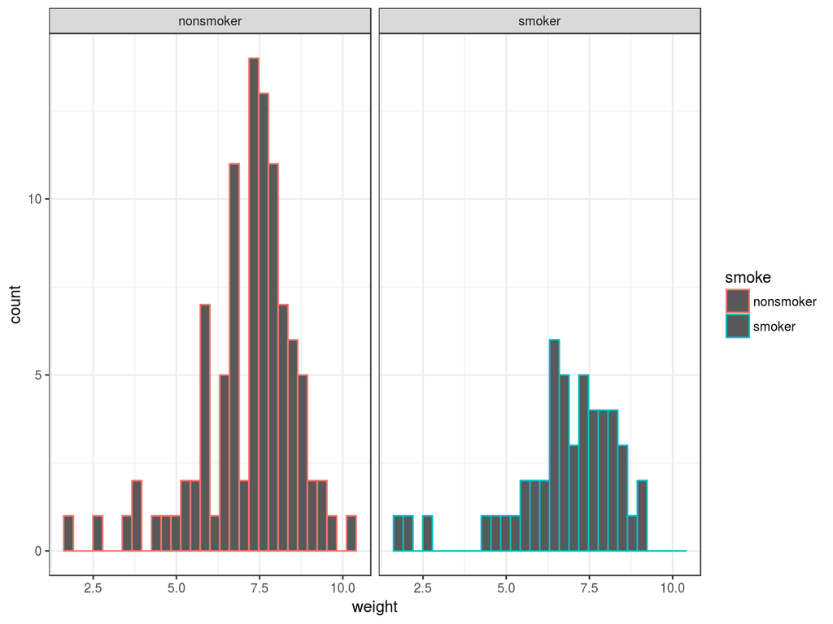

```r
library(ggplot2)
ggplot(births,aes(x = weight)) +
  geom_histogram(aes(colour = smoke)) +
  facet_grid(~ smoke) +
  theme_bw()
```

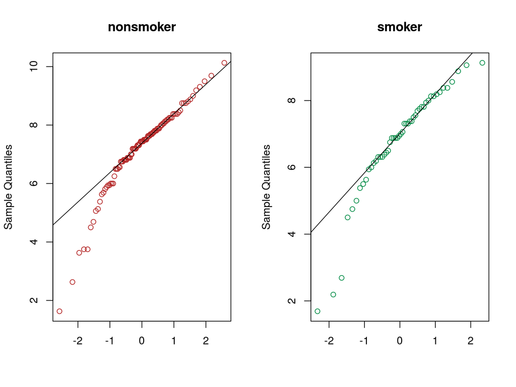

```r
par(mfrow = c(1, 2))
qqnorm(births[births$smoke == "nonsmoker","weight"], xlab = "",
       main = "nonsmoker", col = "firebrick")
qqline(births[births$smoke == "nonsmoker","weight"])
qqnorm(births[births$smoke == "smoker","weight"], xlab = "",
       main = "smoker", col = "springgreen4")
qqline(births[births$smoke == "smoker","weight"])
```

```r
shapiro.test(births[births$smoke == "smoker","weight"])
```

```
##
##  Shapiro-Wilk normality test
##
## data:  births[births$smoke == "smoker", "weight"]
## W = 0.89491, p-value = 0.0003276
```

```r
shapiro.test(births[births$smoke == "nonsmoker","weight"])
```

```
##
##  Shapiro-Wilk normality test
##
## data:  births[births$smoke == "nonsmoker", "weight"]
## W = 0.92374, p-value = 2.234e-05
```

- Homocedasticidad

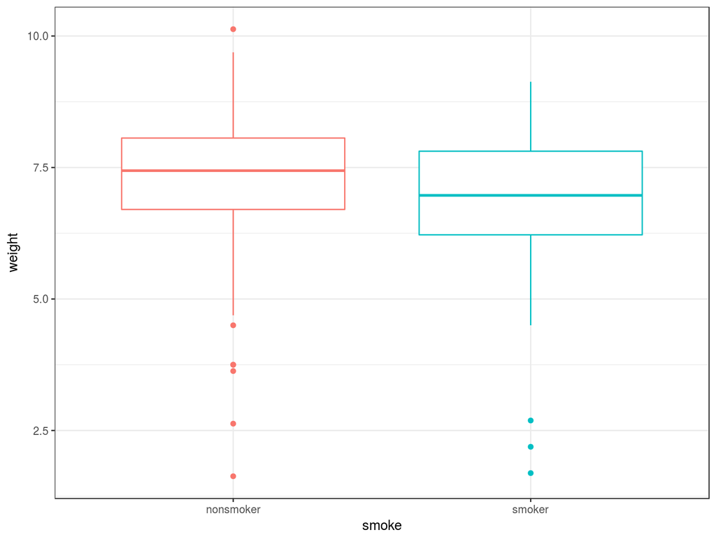

```r
library(car)
leveneTest(weight ~ smoke, data = births, center = "median")
```

```
## Levene's Test for Homogeneity of Variance (center = "median")
##        Df F value Pr(>F)
## group   1  0.4442 0.5062
##       148
```

- Independencia
4. Nivel de significancia $\alpha$

$$\alpha=0.05$$

5. Obtener el valor P.

```r
t.test(x = births[births$smoke == "smoker", "weight"],
       y = births[births$smoke == "nonsmoker", "weight"],
       alternative = "two.sided", mu = 0, var.equal = TRUE, conf.level = 0.95)
```

```
##
##  Two Sample t-test
##
## data:  births[births$smoke == "smoker", "weight"] and births[births$smoke == "nonsmoker", "weight"]
## t = -1.5517, df = 148, p-value = 0.1229
## alternative hypothesis: true difference in means is not equal to 0
## 95 percent confidence interval:
##  -0.9105531  0.1095531
## sample estimates:
## mean of x mean of y
##    6.7790    7.1795
```